# Comparison of TE insertions found on samples Gemelos_21-061 and Gemelos_21-165

## Sample2

**Click to show unique insertions in Gemelos_21-165 (31 rows)**

Inserciones unicas en Gemelos_21-165

| Position | INS Id | Length (bp) | Type | Population allele frequency |
| --- | --- | --- | --- | --- |
| CP068255.2:54 851 870 | seq88979 | 4 697 | LINE (L1HS) | 0.25 |
| CP068255.2:531 429 | seq87919 | 159 | SINE (AluSx) | 0.25 |
| CP068256.2:50 173 993 | seq87789 | 151 | LTR (LTR12E) | 0.25 |
| CP068262.2:96 325 343 | seq72558 | 332 | SINE (AluYb8) | 0.25 |
| CP068263.2:53 913 580 | seq68538 | 183 | Retroposon (SVA_F) | 0.50 |
| CP068263.2:53 913 806 | seq68540 | 51 | Retroposon (SVA_F) | 0.25 |
| CP068263.2:248 491 | seq66290 | 313 | SINE (AluYa5) | 0.25 |
| CP068264.2:67 743 055 | seq65325 | 1 418 | LTR (LTR12E) | 0.25 |
| CP068264.2:67 743 505 | seq65326 | 719 | LTR (LTR12_v) | 0.25 |
| CP068266.2:56 751 565 | seq56928 | 49 | Retroposon (SVA_C) | 0.50 |
| CP068266.2:122 704 283 | seq58438 | 49 | Retroposon (SVA_F) | 0.50 |
| CP068267.2:61 228 568 | seq53715 | 427 | LTR (LTR12E) | 0.25 |
| CP068268.2:5 002 348 | seq48390 | 326 | SINE (AluY) | 0.25 |
| CP068268.2:47 347 072 | seq49998 | 319 | SINE (AluYa5) | 0.25 |
| CP068269.2:6 664 828 | seq39963 | 136 | SINE (AluY) | 0.25 |
| CP068269.2:41 633 588 | seq40791 | 68 | LINE (L1PA2) | 0.50 |
| CP068269.2:41 696 039 | seq40800 | 85 | LINE (L1P4b) | 0.50 |
| CP068269.2:149 526 408 | seq47938 | 201 | Retroposon (SVA_E) | 0.25 |
| CP068269.2:149 526 435 | seq47939 | 125 | Retroposon (SVA_F) | 0.25 |
| CP068270.2:12 704 301 | seq36898 | 938 | LTR (LTR5_Hs) | 0.25 |
| CP068271.2:103 937 188 | seq34419 | 128 | SINE (AluJb) | 0.50 |
| CP068272.2:15 288 768 | seq27425 | 50 | Retroposon (SVA_F) | 0.25 |
| CP068273.2:169 178 185 | seq26479 | 49 | Retroposon (SVA_F) | 0.25 |
| CP068273.2:173 656 926 | seq26610 | 118 | LINE (L1M5) | 0.25 |
| CP068274.2:49 557 557 | seq18382 | 51 | SINE (Alu) | 0.25 |
| CP068274.2:83 303 273 | seq19277 | 6 049 | LINE (L1HS) | 0.25 |
| CP068276.2:44 594 088 | seq7768 | 225 | Retroposon (SVA_E) | 0.25 |
| CP068276.2:100 904 186 | seq9166 | 61 | LINE (L1MD) | 0.50 |
| CP068276.2:110 486 445 | seq9334 | 116 | Retroposon (SVA_D) | 0.50 |
| CP086569.2:1 131 509 | seq90828 | 183 | SINE (AluSx) | 0.50 |
| CP086569.2:563 387 | seq90761 | 168 | SINE (AluJo) | 0.50 |

# Distribution per chromosome

## Sample 1

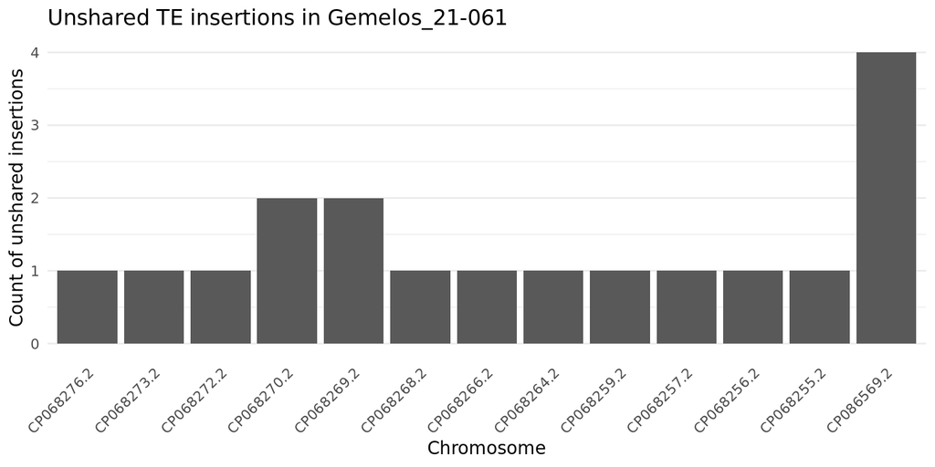

## Sample 2

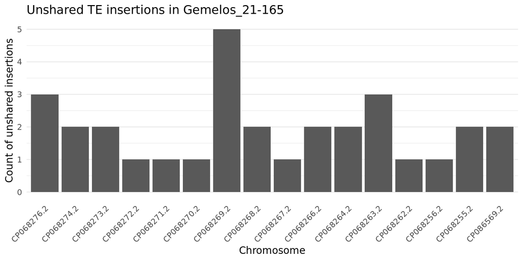

# Shared insertions

With the same methodology than the one used for unshared insertions (checking also for calls that did not pass the strict criterion), 2 022 are reported as shared between both samples.

## Shared insertions by class

[output not shown]

## Annotation of shared insertions

In the table below is shown the gene annotation for shared insertions.

**Click to show table with 1 205 rows.**

**Note**: Annotation type is as described by R package annotatr: “cds”: coding sequences, “promoter”: regulatory region up to 1kb uptream, “1to5kb”: regulatory region between 1 and 5kb upstream, “genes” and “introns”: literal meaning.

| Position | INS Id | Gene symbol | Gene Id | Annotation type |
| --- | --- | --- | --- | --- |
| CP068255.2:5 749 733 | seq88178 | NLGN4X | XM_054327452.1 | introns |
| CP068255.2:7 494 814 | seq88197 | LOC107985675 | XR_007091097.1 | introns |
| CP068255.2:9 615 362 | seq88271 | WWC3 | NM_015691.5 | introns |
| CP068255.2:18 657 080 | seq88398 | ADGRG2 | XM_054326337.1 | introns |
| CP068255.2:22 237 816 | seq88433 | PTCHD1-AS | NR_073010.2 | introns |
| CP068255.2:24 293 369 | seq88480 | POLA1 | XM_054327253.1 | introns |
| CP068255.2:28 925 984 | seq88564 | IL1RAPL1 | NM_014271.4 | introns |
| CP068255.2:32 788 943 | seq88646 | DMD | NM_004006.3 | introns |
| CP068255.2:39 481 305 | seq88726 | BCOR | XM_054327302.1 | introns |
| CP068255.2:83 656 505 | seq89323 | SATL1 | NM_001367857.2 | introns |
| CP068255.2:83 683 173 | seq89325 | ZNF711 | NM_001330574.2 | introns |
| CP068255.2:84 713 986 | seq89333 | DACH2 | XM_054326429.1 | introns |
| CP068255.2:90 623 038 | seq89510 | PCDH11X | NM_032968.5 | introns |
| CP068255.2:97 133 746 | seq89632 | LINC03077 | NR_186574.1 | introns |
| CP068255.2:100 344 903 | seq89686 | ZMAT1 | NM_001011657.4 | introns |
| CP068255.2:102 352 991 | seq89743 | TMSB15B-AS1 | NR_146557.1 | introns |
| CP068255.2:103 670 854 | seq89762 | IL1RAPL2 | NM_017416.2 | introns |
| CP068255.2:110 764 583 | seq89849 | RTL4 | NM_001004308.3 | introns |
| CP068255.2:130 112 151 | seq90196 | FIRRE | NR_152876.1 | introns |
| CP068255.2:151 099 729 | seq90656 | NSDHL | NM_001129765.2 | introns |
| CP068255.2:295 081 | seq87886 | LOC102724521 | XR_008485519.1 | introns |
| CP068256.2:7 583 739 | seq85740 | LOC128966699 | XR_008485442.1 | promoters |
| CP068256.2:18 235 398 | seq86574 | SLC25A18 | NM_001303484.2 | introns |
|  |  | LOC105372850 | XR_007090425.1 | introns |
| CP068256.2:18 700 162 | seq86605 | LINC01634 | NR_024417.1 | promoters |
| CP068256.2:24 409 922 | seq86849 | GSTT4 | XM_054325478.1 | introns |
| CP068256.2:25 461 789 | seq86873 | KIAA1671 | NM_001386930.1 | introns |
| CP068256.2:25 532 879 | seq86878 | KIAA1671 | NM_001386930.1 | introns |
| CP068256.2:27 234 737 | seq86944 | MIATNB | NR_110543.1 | introns |
| CP068256.2:29 242 941 | seq86999 | CCDC117 | NM_001284263.2 | introns |

[output cut: 1175 more lines]

## Full list

This is the list of insertions found shared between both samples, alongside its allele frequency inside the whole population (all the cases in your pipeline) and which sample it was found in.

**Click to show table with 2 022 rows.**

| Position | seqId | Length (bp) | Type | Population allele frequency | Present in sample |
| --- | --- | --- | --- | --- | --- |
| CP068255.2:3 778 904 | seq88104 | 57 | LINE (L1PB1) | 1.00 | Gemelos_21-061 |
| CP068255.2:4 531 817 | seq88130 | 314 | SINE (AluYa5) | 0.50 | Gemelos_21-165 |
| CP068255.2:5 749 733 | seq88178 | 113 | SINE (AluY) | 0.50 | Gemelos_21-061 |
| CP068255.2:7 494 814 | seq88197 | 158 | SINE (AluYa5) | 0.50 | Gemelos_21-165 |
| CP068255.2:9 615 362 | seq88271 | 270 | SINE (AluSx) | 0.25 | Gemelos_21-061 |
| CP068255.2:18 657 080 | seq88398 | 54 | SINE (AluJb) | 0.50 | Gemelos_21-165 |
| CP068255.2:22 237 816 | seq88433 | 314 | SINE (AluY) | 0.50 | Gemelos_21-061 |
| CP068255.2:24 293 369 | seq88480 | 129 | Retroposon (SVA_F) | 1.00 | Gemelos_21-165 |
| CP068255.2:25 517 581 | seq88494 | 334 | SINE (AluYb8) | 1.00 | Gemelos_21-061 |
| CP068255.2:25 603 542 | seq88498 | 112 | LINE (L1M3) | 0.50 | Gemelos_21-165 |
| CP068255.2:27 034 647 | seq88533 | 90 | LTR (MER61C) | 1.00 | Gemelos_21-061 |
| CP068255.2:28 925 984 | seq88564 | 49 | Retroposon (SVA_F) | 1.00 | Gemelos_21-165 |
| CP068255.2:30 241 729 | seq88584 | 321 | SINE (AluYe5) | 0.50 | Gemelos_21-061 |
| CP068255.2:32 788 943 | seq88646 | 323 | SINE (AluYb8) | 0.50 | Gemelos_21-165 |
| CP068255.2:39 481 305 | seq88726 | 337 | SINE (AluYb8) | 0.50 | Gemelos_21-061 |
| CP068255.2:43 924 387 | seq88785 | 128 | SINE (FLAM_C) | 0.50 | Gemelos_21-165 |
| CP068255.2:45 336 176 | seq88808 | 236 | LINE (L1M5) | 0.75 | Gemelos_21-061 |
| CP068255.2:45 683 112 | seq88822 | 125 | Retroposon (SVA_F) | 1.00 | Gemelos_21-165 |
| CP068255.2:52 216 963 | seq88931 | 324 | SINE (AluYb8) | 1.00 | Gemelos_21-061 |
| CP068255.2:56 310 479 | seq89004 | 309 | LINE (L1P2) | 0.50 | Gemelos_21-165 |
| CP068255.2:56 311 246 | seq89005 | 123 | LINE (L1P1) | 0.50 | Gemelos_21-061 |
| CP068255.2:61 614 010 | seq89039 | 227 | Retroposon (SVA_E) | 0.50 | Gemelos_21-165 |
| CP068255.2:69 349 478 | seq89124 | 335 | SINE (AluYb8) | 0.50 | Gemelos_21-061 |
| CP068255.2:76 878 721 | seq89207 | 597 | LINE (L1HS) | 0.50 | Gemelos_21-165 |
| CP068255.2:78 249 308 | seq89244 | 294 | SINE (AluYa5) | 0.50 | Gemelos_21-061 |
| CP068255.2:82 985 846 | seq89308 | 1 752 | LINE (L1M1) | 0.25 | Gemelos_21-165 |
| CP068255.2:83 038 219 | seq89310 | 351 | LINE (L1PB) | 0.50 | Gemelos_21-061 |
| CP068255.2:83 656 505 | seq89323 | 86 | LINE (L1MC5) | 1.00 | Gemelos_21-165 |
| CP068255.2:83 683 173 | seq89325 | 323 | SINE (AluY) | 0.75 | Gemelos_21-061 |
| CP068255.2:84 713 986 | seq89333 | 317 | SINE (AluYa5) | 0.50 | Gemelos_21-165 |

[output cut: 3942 more lines]